# Student clusters based on sequences of HMM states before and after midterm

The first part of the analysis consists of creating *2 Hidden Markov Models (HMMs)*, one for the first part of the course, and one for the 2nd part, where the midterm exam is used as the delimiter. So, the 1st part of the course includes weeks 2 to 5, whereas the 2nd lasts from week 7 to 12. Weeks 6 and 13 are not considered as those are the weeks when students prepare for the exams and their behaviour deviates from the regular study behaviour.

For both HMMs student-session is used as the unit of analysis, that is, student learning actions are examined at the level of study sessions (instead of the week level as done previously). Study sessions are identified based on the time gap between consecutive learning actions.

For each study session, the following features are computed:

- FA_PERC - percentage (ratio) of formative assessment actions within the study session
- FA_CO_PERC - percentage (or ratio) of correct formative assessment actions
- SA_PERC - percentage (ratio) of summative assessment actions within the study session
- SA_CO_PERC - percentage (or ratio) of correct summative assessment actions
- VID_PERC - percentage (ratio) of video play actions within the study session
- READ_PERC - percentage (ratio) of reading (content access) actions within the study session
- METACOG_PERC - percentage (ratio) of metacognitive (dashboard + orientation) actions within the study session

## Loading and preparing the data

```r
# load the data
traces <- readRDS(file = "Intermediate_results/study_mode_weeks2-13.RData")
str(traces)
```

```
'data.frame':   598201 obs. of  9 variables:
 $ STUDENT_ID: int  5 5 5 5 5 5 5 5 5 5 ...
 $ ACTION    : Factor w/ 15 levels "CONTENT_ACCESS",..: 1 15 1 1 1 11 15 15 15 15 ...
 $ TIMESTAMP : POSIXlt, format: "2015-08-03 12:57:21" "2015-08-03 12:58:30" "2015-08-03 15:22:38" ...
 $ WEEK      : int  2 2 2 2 2 2 2 2 2 2 ...
 $ TOPIC     : chr  "COD" "COD" "COD" "CST" ...
 $ TIME_GAP  : num  NA 1.147 144.131 26.781 0.184 ...
 $ SESSION_ID: num  1 1 2 3 3 3 3 3 3 3 ...
 $ TOPIC_WEEK: num  2 2 2 1 2 2 2 2 2 2 ...
 $ STUDY_MODE: Factor w/ 5 levels "ahead","catching-up",..: 3 3 3 2 3 3 3 3 3 3 ...
```

```r
# load the required functions
source(file = "functions_for_analyzing_seq_of_HMM_states.R")
```

```r
# remove traces originating from weeks 6 and 13
selected.traces <- subset(traces, WEEK %in% c(2:5,7:12))
# the last two columns are not needed, and can be removed
selected.traces <- selected.traces[,c(1:7)]
```

By removing data from weeks 6 and 13, 77.98% of the initial traces (N=598201) are left for further analysis.

The distribution of events across the course weeks (weeks 6 and 13 have been removed):

```r
require(knitr)
kable(t(table(selected.traces$WEEK)))
```

| 2 | 3 | 4 | 5 | 7 | 8 | 9 | 10 | 11 | 12 |
| --- | --- | --- | --- | --- | --- | --- | --- | --- | --- |
| 70140 | 76908 | 66354 | 62360 | 24976 | 38839 | 36552 | 29423 | 31024 | 29924 |

There is significantly higher level of activity in the weeks 2, 3, 4 and 5 than in the subsequent weeks.

Counts and proportions of different kinds of learning actions:

```r
table(selected.traces$ACTION)
```

```
CONTENT_ACCESS          FA_CO          FA_IN          FA_SR        MC_EVAL      MC_ORIENT
         72466          54523          42303           9466          12242           4906
         SA_CO          SA_IN       VIDEO_PA       VIDEO_PL
         63239          91201          48999          67155
```

```r
round(prop.table(table(selected.traces$ACTION)), digits = 4)
```

```
CONTENT_ACCESS          FA_CO          FA_IN          FA_SR        MC_EVAL      MC_ORIENT
        0.1553         0.1169         0.0907         0.0203         0.0262         0.0105
         SA_CO          SA_IN       VIDEO_PA       VIDEO_PL
        0.1356         0.1955         0.1050         0.1440
```

```r
# re-examine the splitting of actions into sessions
summary(sorted.traces$TIME_GAP)
```

```
    Min.  1st Qu.   Median     Mean  3rd Qu.     Max.     NA's
   0.000    0.051    0.121   11.600    0.498 1440.000     6733
```

```r
quantile(sorted.traces$TIME_GAP, probs = seq(0.9,1,0.01), na.rm = T)
```

```
        90%         91%         92%         93%         94%         95%         96%
   2.367551    2.826324    3.465609    4.408001    5.792119    8.016738   12.094393
        97%         98%         99%        100%
  21.575171   62.320770  485.559090 1439.720790
```

Use the time gap of 21 min (~97th percentile) as the ‘session delimiter’. Why 97th? 95th (8 min) and 96th (12 min) seem to be insufficiently long considering the length of videos, whereas 98th is overly long (62 min); furthermore, 21 min is the time gap used to delimit sessions in the 2014 dataset.

Using 21 min time gap between events as the session delimiter, the events of 371 students are split into 20701 study sessions.

Remove students who do not have at least one session in each of the 2 time periods (weeks 2-5 and 7-12):

```r
traces.w2to5 <- subset(sorted.traces, WEEK %in% c(2:5))
s.count.2to5 <- get.session.count(traces.w2to5)
summary(s.count.2to5)
```

```
   Min. 1st Qu.  Median    Mean 3rd Qu.    Max.
   1.00   17.00   26.00   30.04   38.50  108.00
```

```r
sort(s.count.2to5)[1:20]
```

```
 [1] 1 2 2 4 4 5 6 6 7 7 7 7 7 7 7 7 7 8 8 8
```

1 student(s) with only 1 session in weeks 2-5.

```r
traces.w7to12 <- subset(sorted.traces, WEEK %in% c(7:12))
s.count.7to12 <- get.session.count(traces.w7to12)
summary(s.count.7to12)
```

```
   Min. 1st Qu.  Median    Mean 3rd Qu.    Max.
   2.00   14.00   21.50   25.96   33.00  110.00
```

```r
sort(s.count.7to12)[1:20]
```

```
 [1] 2 4 5 5 5 6 6 6 6 6 6 6 7 7 7 7 7 7 7 7
```

0 student(s) with only 1 session in weeks 7-12.

Check for outliers:

```r
## check for outliers in weeks 2-5
boxplot.stats(s.count.2to5)$out
```

```
 [1] 108  71  86  84  77  72  74  76  72  82  74  71 103  74  71  78
```

```r
sort(s.count.2to5, decreasing = T)[1:20]
```

```
 [1] 108 103  86  84  82  78  77  76  74  74  74  72  72  71  71  71  70  68  67  66
```

```r
extremes.w2to5 <- sort(s.count.2to5, decreasing = T)[1:2]
```

Several outliers in weeks 2-5, but only two extreme: 108, 103

```r
## check for outliers in weeks 7-12
boxplot.stats(s.count.7to12)$out
```

```
 [1]  64  63  70  66  74  85  73  62  71  77  65  62  79 110  64  74
```

```r
sort(s.count.7to12, decreasing = T)[1:20]
```

```
 [1] 110  85  79  77  74  74  73  71  70  66  65  64  64  63  62  62  60  59  59  58
```

```r
extremes.w7to12 <- sort(s.count.7to12, decreasing = T)[1:2]
```

Also, several outliers in weeks 7-12, but only two extreme: 110, 85

Apply a “light-weight” version of outliers removal - removing only “extreme” outliers. Also remove the student with only 1 session (in weeks 2-5):

Re-compute session counts (after the removal of extreme outliers)

```r
s.count.2to5 <- get.session.count(traces.w2to5)
boxplot.stats(s.count.2to5)$out
```

```
 [1] 71 86 70 84 77 72 74 76 72 82 74 71 74 71 78
```

```r
s.count.7to12 <- get.session.count(traces.w7to12)
boxplot.stats(s.count.7to12)$out
```

```
 [1] 64 63 70 66 74 73 62 71 77 65 62 79 64 74
```

Still several outliers, but will keep them for now.

Keep only students who had sessions in both periods (2-5 and 7-12)

Check the number of students and sessions after the cleaning

```r
(paste("number of students:", length(stud.ids), "; initially, there were:", n.stud, "students"))
```

```
[1] "number of students: 364 ; initially, there were: 371 students"
```

```r
n.sessions.w2to5 <- length(unique(traces.w2to5$SESSION_ID))
(paste("number of sessions in weeks 2-5:", n.sessions.w2to5))
```

```
[1] "number of sessions in weeks 2-5: 10822"
```

```r
n.sessions.w7to12 <- length(unique(traces.w7to12$SESSION_ID))
(paste("number of sessions in weeks 7-12:", n.sessions.w7to12))
```

```
[1] "number of sessions in weeks 7-12: 9255"
```

```r
(paste("total sessions: ", n.sessions.w2to5+n.sessions.w7to12, "; initially, there were:", n.sessions, "sessions"))
```

```
[1] "total sessions:  20077 ; initially, there were: 20701 sessions"
```

## Compute features for HMMs

Compute separate feature sets for weeks 2-5 and weeks 7-12. Features are computed for each student and each session.

### Compute features for weeks 2-5

```r
## create a list of study sessions for each student
stud.sessions <- list()
for(s in 1:length(stud.ids)) {
  stud.sessions[[s]] <- unique(traces.w2to5$SESSION_ID[traces.w2to5$STUDENT_ID==stud.ids[s]])
}
## create a data frame with the feature values for weeks 2-5
features.w2to5 <- data.frame()
for(s in 1:length(stud.sessions)) {
  session.features.df <- compute.stud.session.features(stud.sessions[[s]], traces.w2to5)
  session.features.df$STUDENT_ID <- stud.ids[s]
  features.w2to5 <- as.data.frame(rbind(features.w2to5, session.features.df))
}
#str(features.w2to5)
features.w2to5 <- features.w2to5[,c(9,1:8)]
#head(features.w2to5)
## add the ntimes attribute to the feature set (requied for the depmixS4)
ntimes.vector <- compute.ntimes(features.w2to5)
features.w2to5 <- add.ntimes.feature(features.w2to5, ntimes.vector)
str(features.w2to5)
## discretize the feature set
discrete.w2to5 <- discretize.features(features.w2to5)
## turn all the features into factor variables and save the feature set
f.path <- "Intermediate_results/multinom_features_for_session_based_HMM_weeks2to5"
ff.w2to5 <- factorize.and.store(discrete.w2to5, f.path)
```

### Compute features for weeks 7-12

```r
## create a list of study sessions for each student
stud.sessions <- list()
for(s in 1:length(stud.ids)) {
  stud.sessions[[s]] <- unique(traces.w7to12$SESSION_ID[traces.w7to12$STUDENT_ID==stud.ids[s]])
}
## create a data frame with the feature values for weeks 7-12
features.w7to12 <- data.frame()
for(s in 1:length(stud.sessions)) {
  session.features.df <- compute.stud.session.features(stud.sessions[[s]], traces.w7to12)
  session.features.df$STUDENT_ID <- stud.ids[s]
  features.w7to12 <- as.data.frame(rbind(features.w7to12, session.features.df))
}
str(features.w7to12)
features.w7to12 <- features.w7to12[,c(9,1:8)]
#head(features.w7to12)
## add the ntimes attribute to the feature set (requied for the depmixS4)
ntimes.vector <- compute.ntimes(features.w7to12)
features.w7to12 <- add.ntimes.feature(features.w7to12, ntimes.vector)
## discretize the feature set
discrete.w7to12 <- discretize.features(features.w7to12)
## turn all the features into factor variables and save the feature set
f.path <- "Intermediate_results/multinom_features_for_session_based_HMM_weeks7to12"
ff.w7to12 <- factorize.and.store(discrete.w7to12, f.path)
```

## Fit HMM models

### Fit a model for weeks 2-5

Compare models with different number of states:

```r
s <- 742017
compare.models(ff.w2to5, max.ns = 7, seed = s)
```

converged at iteration 54 with logLik: -77754.73 converged at iteration 55 with logLik: -73586.11 converged at iteration 74 with logLik: -70684.34 converged at iteration 41 with logLik: -66975.54 converged at iteration 53 with logLik: -66926.26 converged at iteration 52 with logLik: -65211.68

| n.states | AIC | BIC | logLik |
| --- | --- | --- | --- |
| 2 | 155795.5 | 156837.8 | -77754.73 |
| 3 | 147608.2 | 149197.3 | -73586.11 |
| 4 | 141958.7 | 144109.0 | -70684.34 |
| 5 | 134699.1 | 137425.3 | -66975.54 |
| 6 | 134762.5 | 138079.2 | -66926.26 |
| 7 | 131499.4 | 135421.0 | -65211.68 |

```r
summary(mod.fit.5s)
```

Interpretation of the states:

- **State 1**: A variety of learning actions; equally likely are: i) FA actions (form up to 50% of a session; proportions of correctly done items vary from session to session, but are most likely in the ranges 30-70% and 90-100%), ii) SA actions (forming 10-70% of a session; proportions of correctly done items vary from session to session, but are most likely in the 20-80% range); and iii) reading actions (form up to 30% of a session). There is a solid chance (p~0.6) that video watching forms up to 30% of a session, and also some chance (p~0.5) that metacognitive actions form up to 20% of a session.
- **State 2**: It is highly likely (p~0.8) that metacognitive actions form 90-100% of a session; the rest tend to be filled up by reading actions.
- **State 3**: Reading actions form 90-100% of a session.
- **State 4**: Most likely SA actions form 80-100% of a session, with proportions of correctly done items varying from session to session, but most likely being in the 20-60% range; there is a chance (p~0.45) that reading actions form up to 30% of a session; also, some chance (p~0.3) that metacognitive actions are present with up to 20%, and a small chance (p~0.1) that video watching is slightly present (up to 10%).
- **State 5**: A variety of learning actions: most likely are FA actions with proportions varying from session to session (proportions of correctly done items also vary from session to session, but are most likely in the ranges 40-70% and 90-100%); there is a solid chance (p~0.8) that reading actions form up to 30% of a session; also, some chance (p~0.5) that video watching form up to 50% of a session, and a small chance (p~0.3) that metacognitive actions are present with up to 10%.

### Fit a model for weeks 7-12

Compare models with different number of states:

```r
compare.models(ff.w7to12, max.ns = 7, seed = s)
```

converged at iteration 83 with logLik: -60008.35 converged at iteration 36 with logLik: -54040.2 converged at iteration 43 with logLik: -49787.65 converged at iteration 35 with logLik: -48332.78 converged at iteration 35 with logLik: -47002.85 converged at iteration 52 with logLik: -46282.57

| n.states | AIC | BIC | logLik |
| --- | --- | --- | --- |
| 2 | 120302.70 | 121322.71 | -60008.35 |
| 3 | 108516.40 | 110071.38 | -54040.20 |
| 4 | 100165.31 | 102269.52 | -49787.65 |
| 5 | 97413.57 | 100081.28 | -48332.78 |
| 6 | 94915.70 | 98161.18 | -47002.85 |
| 7 | 93641.14 | 97478.65 | -46282.57 |

```r
mod.fit.4s <- fit.HMM(ff.w7to12, ns = 4, seed = s)
summary(mod.fit.4s)
```

Interpretation of the states:

- **State 1**: It is highly likely (p~0.85) that metacognitive actions form 90-100% of a session; the rest tend to be filled up by reading actions.
- **State 2**: Most likely SA actions form 80-100% of a session, with proportions of correctly done items varying from session to session, but most likely being in the 20-60% range; there is a small chance (p~0.2) that reading actions form up to 20% of a session, and that metacognitive actions are present with up to 10%.
- **State 3**: Reading actions form 90-100% of a session.
- **State 4**: A variety of learning actions: most likely are reading actions (up to 30% of a session); then, FA actions with proportions varying from session to session (proportions of correctly done items also vary from session to session, but are most likely in the 30-60% range); video watching is only slightly less likely than FA (p~0.65), and is expected to fill up to 50% of a session; there is also some chance (p~0.3) that SA actions are present (with proportions varying from session to session); finally, there is a tiny chance (p~0.2) that metacognitive actions form up to 10% of a session.

### Compute and plot the distribution of states

#### First for weeks 2-5

```r
w2to5.dat <- read.csv(file = "results/session_based_HMM_5_states_weeks2to5.csv")
table(w2to5.dat$state)
```

```
   1    2    3    4    5
 961 1801 3948 1080 3032
```

```r
round(prop.table(table(w2to5.dat$state)), digits = 2)
```

```
   1    2    3    4    5
0.09 0.17 0.36 0.10 0.28
```

Plot the state distribution for each student

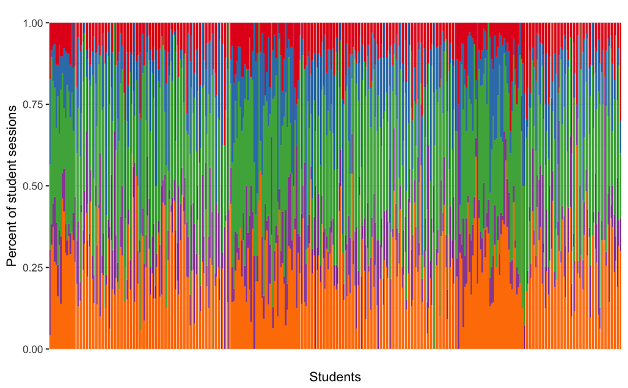

```r
cpallet.5st <- c('#e41a1c','#377eb8','#4daf4a','#984ea3','#ff7f00','#ffff33')
states.perc.long$STUDENT_ID <- factor(states.perc.long$STUDENT_ID)
plot.session.percents(states.perc.long, 5, cpallet.5st)
```

Not very useful…

#### Now, for weeks 7-12

```r
w7to12.dat <- read.csv(file = "results/session_based_HMM_4_states_weeks7to12.csv")
table(w7to12.dat$state)
```

```
   1    2    3    4
1526 1017 3816 2904
```

```r
round(prop.table(table(w7to12.dat$state)), digits = 2)
```

```
   1    2    3    4
0.16 0.11 0.41 0.31
```

Plot the state distribution for each student

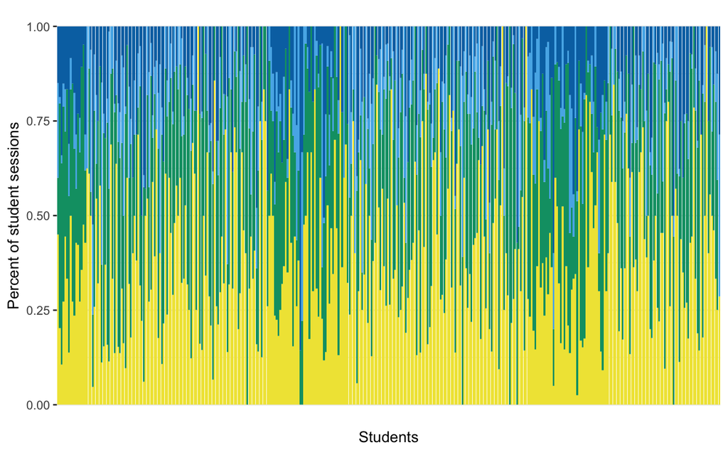

```r
cpallet.4st <- c("#0072B2","#56B4E9", "#009E73", "#F0E442")
states.perc.long$STUDENT_ID <- factor(states.perc.long$STUDENT_ID)
plot.session.percents(states.perc.long, 4, cpallet.4st)
```

## Clustering students based on their state sequences

Each student will be represented with a sequence of states that corresponds to the sequence of his/her learning sessions (states are identified using HMM, and each state corresponds to one learning session).

Sequence clustering will be done separately for the two parts of the course, first, for weeks 2-5, and then for weeks 7-12.

### Sequence clustering for weeks 2-5

Before formatting the data for sequence analysis, it would be good to examine the sequences (of students’ study sessions) to identify the presence of outliers (ie. overly long or short sequences).

```r
seq.len <- compute.seqence.length(w2to5.dat)
summary(seq.len$SESSION_CNT)
```

```
   Min. 1st Qu.  Median    Mean 3rd Qu.    Max.
   2.00   17.00   26.00   29.73   38.00   86.00
```

```r
boxplot.stats(seq.len$SESSION_CNT)$out
```

```
 [1] 71 86 84 77 72 74 76 72 82 74 71 74 71 78
```

```r
# 14 outliers
sort(seq.len$SESSION_CNT, decreasing = T)[1:20]
```

```
 [1] 86 84 82 78 77 76 74 74 74 72 72 71 71 71 68 67 66 66 63 62
```

```r
# maybe remove just the "extreme" outliers?
```

```r
## better also examine percentiles
quantile(x = seq.len$SESSION_CNT, probs = seq(0, 0.1, 0.01))
```

```
   0%    1%    2%    3%    4%    5%    6%    7%    8%    9%   10%
 2.00  5.63  7.00  7.00  7.52  8.00  8.78  9.00 10.00 10.00 11.00
```

```r
quantile(x = seq.len$SESSION_CNT, probs = seq(0.9, 1, 0.01))
```

```
  90%   91%   92%   93%   94%   95%   96%   97%   98%   99%  100%
53.00 55.33 56.00 57.59 60.22 62.85 67.48 71.11 74.00 77.37 86.00
```

Remove those students whose number of sessions is less than the 1st perc (5.6) or greater than the 99th perc (77.4); this way, 2% of students will be removed.

```r
to.remove <- seq.len$STUDENT_ID[seq.len$SESSION_CNT < 5.63]
to.remove <- c(to.remove, seq.len$STUDENT_ID[seq.len$SESSION_CNT > 77.4])
# 8 students in total (2.2%)
seq.w2to5 <- subset(w2to5.dat, !(STUDENT_ID %in% to.remove))
# 10463  (96.81% of the initial 10808 sessions)
```

#### Now, do sequence clustering

First, compute dissimilarities among sequences using the Optimal Matching method; to compute the dissimilarities, we need a substitution-cost matrix. Since we have transition probabilities from one state to the next - obtained from the HMM method - we can use these to compute the substitution costs; using the following formula (from TraMineR documentation): SC(i,j) = cval - p(i,j) - p(j,i) where cval is, by default, equal to 2

```r
ns <- 5
state.trans.matrix <- matrix(data = c(0.071, 0.248, 0.352, 0.130, 0.199,
                                      0.081, 0.288, 0.323, 0.103, 0.205,
                                      0.083, 0.125, 0.453, 0.075, 0.263,
                                      0.050, 0.152, 0.365, 0.202, 0.231,
                                      0.120, 0.126, 0.276, 0.085, 0.393),
                             nrow = ns, ncol = ns, byrow = T,
                             dimnames = list(seq(1,ns,1), seq(1,ns,1)))
cost.matrix <- compute.cost.matrix(state.trans.matrix, n.state = 5)
cost.matrix
```

```
      [,1]  [,2]  [,3]  [,4]  [,5]
[1,] 0.000 1.671 1.565 1.820 1.681
[2,] 1.671 0.000 1.552 1.745 1.669
[3,] 1.565 1.552 0.000 1.560 1.461
[4,] 1.820 1.745 1.560 0.000 1.684
[5,] 1.681 1.669 1.461 1.684 0.000
```

```r
## normalize the computed distances to account for differences in sequence lengths
dist.om1.5 <- seqdist(seqdata = traminer.seq, method = "OM",
                       sm = cost.matrix, norm = T, indel = 1.5)
# dist.om2 <- seqdist(seqdata = traminer.seq, method = "OM",
#                     sm = cost.matrix, norm = T, indel = 2)
require(cluster)
set.seed(742017)
seq.ward <- agnes(dist.om1.5, diss = T, method = "ward")
png(file = "graphics/w2to5_seq.ward_dist.om1.5.png",
    width = 1800, height = 1500, pointsize = 50)
plot(seq.ward)
dev.off()
```

```
clusters
  1   2   3   4   5
 39  67 110 117  23
```

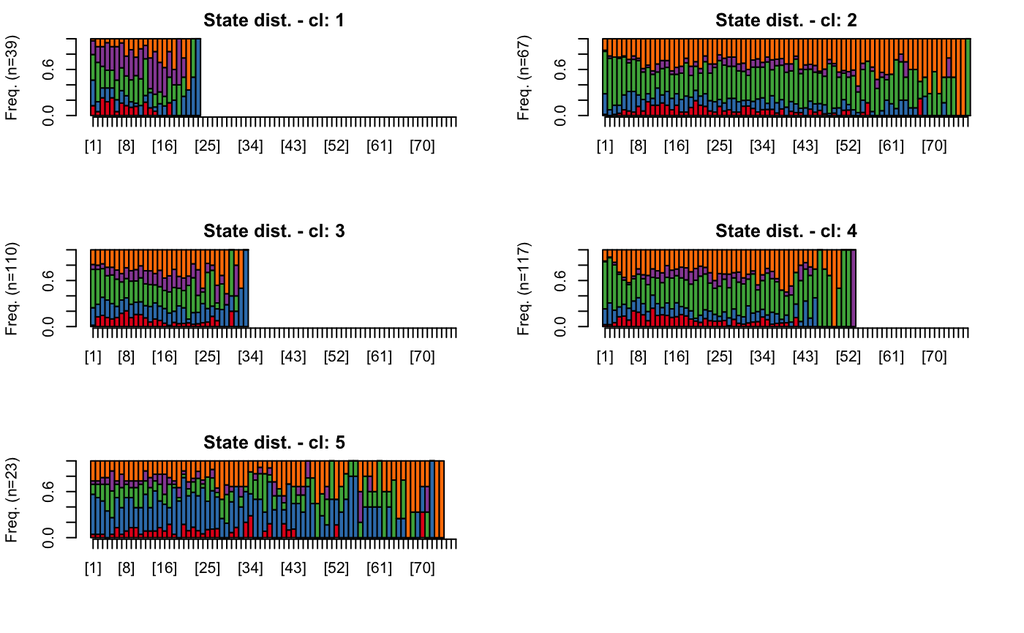

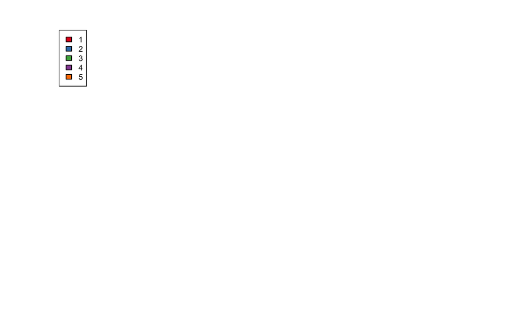

```r
## check the solution with 5 clusters
cl5 <- examine.clusters(cl.mod = seq.ward, n.clust = 5,
                        custom.pallet = cpallet.5st)
```

```
clusters
  1   2   3   4
 39  90 110 117
```

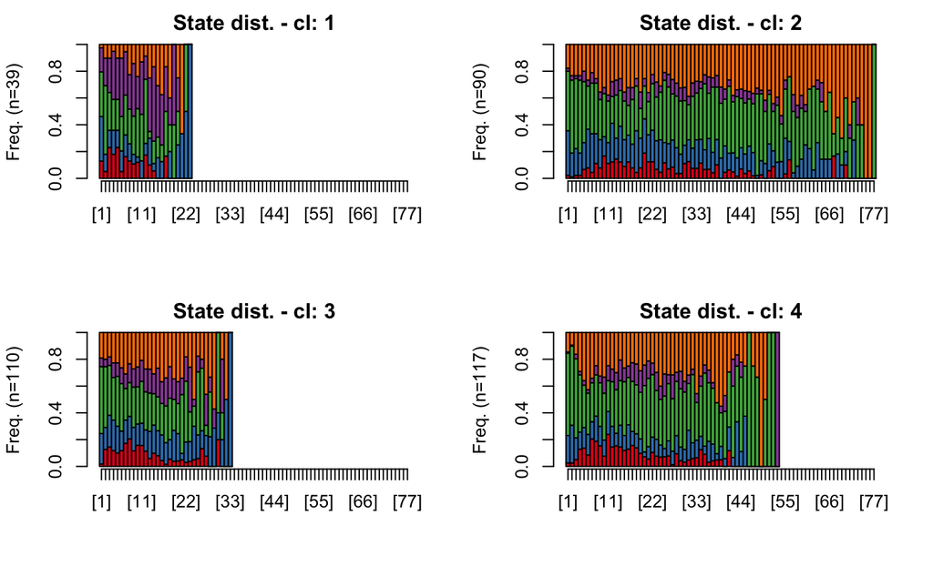

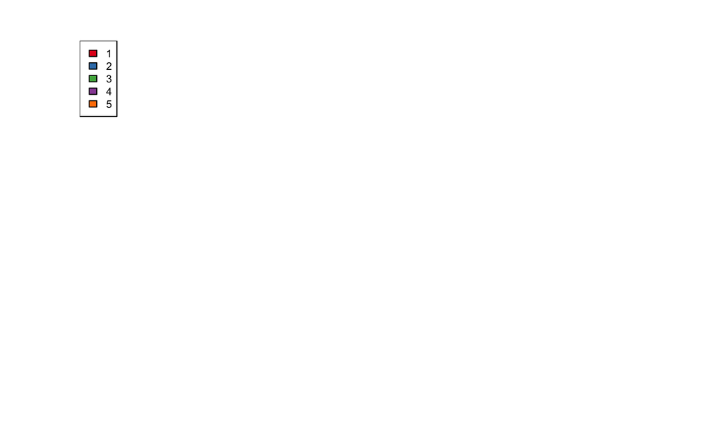

```r
## check the solution with 4 clusters
cl4 <- examine.clusters(cl.mod = seq.ward, n.clust = 4, cpallet.5st)
```

#### Compare the clusters w.r.t. the students’ exam (midterm and final) scores

##### Examine first the 4 clusters model

Summary statistics for the students’ exam scores:

```r
## compute the summary statistics for the students' exam scores
cl4.stats <- summary.stats(clusts.w2to5[,c(5,6)], clusts.w2to5$cl4, 4)
kable(x = cl4.stats)
```

| attributes | Median; (Q1, Q3) | Median; (Q1, Q3) | Median; (Q1, Q3) | Median; (Q1, Q3) |
| --- | --- | --- | --- | --- |
| cluster | 1 | 2 | 3 | 4 |
| freq | 39 | 90 | 110 | 117 |
| SC_FE_TOT | 16.67; (10, 26.33) | 22.83; (17.5, 31.92) | 17.83; (11, 24.58) | 23.33; (16.67, 30.67) |
| SC_MT_TOT | 12; (9, 16.5) | 17; (14, 18.25) | 14; (10, 16) | 16; (14, 18) |

The final exam score is not normaly distributed (checked before); using non-parametric (Kruskal-Wallis) test to examine differences across the clusters

```r
kruskal.test(clusts.w2to5$SC_FE_TOT ~ clusts.w2to5$cl4)
```

```
    Kruskal-Wallis rank sum test

data:  clusts.w2to5$SC_FE_TOT by clusts.w2to5$cl4
Kruskal-Wallis chi-squared = 26.363, df = 3, p-value = 8.007e-06
```

Since the Kruskal-Wallis test indicated significant differences among the clusters, do pair-wise comparisons using the Mann-Whitney U Test; FDR correction is applied to avoid family-wise error:

```r
stud.4cl.df <- clusts.w2to5[,c(1,3,5,6)]
colnames(stud.4cl.df)[2] <- "class"
kable(pairwise.exam.compare(4, 6, stud.4cl.df, "FE"))
```

|  | c1 | c2 | Z | p | r | significant | alpha |
| --- | --- | --- | --- | --- | --- | --- | --- |
| 6 | 3 | 4 | -3.8811 | 0.000091 | 0.2576 | YES | 0.0083333 |
| 4 | 2 | 3 | 3.8267 | 0.000112 | 0.2706 | YES | 0.0166667 |
| 1 | 1 | 2 | -3.2827 | 0.000897 | 0.2890 | YES | 0.0250000 |
| 3 | 1 | 4 | -3.1641 | 0.001395 | 0.2533 | YES | 0.0333333 |
| 2 | 1 | 3 | -0.5097 | 0.612420 | 0.0418 | NO | 0.0416667 |
| 5 | 2 | 4 | 0.3307 | 0.741893 | 0.0230 | NO | 0.0500000 |

Check the difference based on the midterm score:

```r
kruskal.test(clusts.w2to5$SC_MT_TOT ~ clusts.w2to5$cl4)
```

```
    Kruskal-Wallis rank sum test

data:  clusts.w2to5$SC_MT_TOT by clusts.w2to5$cl4
Kruskal-Wallis chi-squared = 39.584, df = 3, p-value = 1.305e-08
```

Apply Mann-Whitney U Test (with FDR correction) to do pair-wise comparisons:

```r
kable(pairwise.exam.compare(4, 6, stud.4cl.df, "MT"))
```

|  | c1 | c2 | Z | p | r | significant | alpha |
| --- | --- | --- | --- | --- | --- | --- | --- |
| 4 | 2 | 3 | 5.0484 | 0.000000 | 0.3570 | YES | 0.0083333 |
| 1 | 1 | 2 | -4.2720 | 0.000012 | 0.3761 | YES | 0.0166667 |
| 6 | 3 | 4 | -4.2599 | 0.000017 | 0.2827 | YES | 0.0250000 |
| 3 | 1 | 4 | -3.5915 | 0.000269 | 0.2876 | YES | 0.0333333 |
| 5 | 2 | 4 | 1.3675 | 0.172013 | 0.0950 | NO | 0.0416667 |
| 2 | 1 | 3 | -0.8925 | 0.374220 | 0.0731 | NO | 0.0500000 |

For both midterm and final exams, there is a significant difference between 4 out of 6 pairs of clusters; the difference is not present between cluster pairs 1-3 and 2-4. In this case, midterm exam is more important since clusters are based on student behaviour before the midterm.

##### Now, examine the 5 clusters model

Compute the summary statistics for the students’ exam scores

```r
cl5.stats <- summary.stats(clusts.w2to5[,c(5,6)], clusts.w2to5$cl5, 5)
kable(x = cl5.stats)
```

| attributes | Median; (Q1, Q3) | Median; (Q1, Q3) | Median; (Q1, Q3) | Median; (Q1, Q3) | Median; (Q1, Q3) |
| --- | --- | --- | --- | --- | --- |
| cluster | 1 | 2 | 3 | 4 | 5 |
| freq | 39 | 67 | 110 | 117 | 23 |
| SC_FE_TOT | 16.67; (10, 26.33) | 23; (17.67, 32.67) | 17.83; (11, 24.58) | 23.33; (16.67, 30.67) | 20.67; (17.33, 28.33) |
| SC_MT_TOT | 12; (9, 16.5) | 17; (14, 19) | 14; (10, 16) | 16; (14, 18) | 16; (14, 18) |

Using Kruskal-Wallis test to examine differences across the 5 clusters:

```r
kruskal.test(clusts.w2to5$SC_FE_TOT ~ clusts.w2to5$cl5)
```

```
    Kruskal-Wallis rank sum test

data:  clusts.w2to5$SC_FE_TOT by clusts.w2to5$cl5
Kruskal-Wallis chi-squared = 26.93, df = 4, p-value = 2.054e-05
```

Pair-wise comparisons using the Mann-Whitney U Test (with FDR correction):

```r
stud.5cl.df <- clusts.w2to5[,c(1,2,5,6)]
colnames(stud.5cl.df)[2] <- "class"
kable(pairwise.exam.compare(5, 10, stud.5cl.df, "FE"))
```

|  | c1 | c2 | Z | p | r | significant | alpha |
| --- | --- | --- | --- | --- | --- | --- | --- |
| 8 | 3 | 4 | -3.8811 | 0.000091 | 0.2576 | YES | 0.005 |
| 5 | 2 | 3 | 3.7772 | 0.000134 | 0.2839 | YES | 0.010 |
| 1 | 1 | 2 | -3.3577 | 0.000667 | 0.3261 | YES | 0.015 |
| 3 | 1 | 4 | -3.1641 | 0.001395 | 0.2533 | YES | 0.020 |
| 4 | 1 | 5 | -1.8658 | 0.062251 | 0.2370 | NO | 0.025 |
| 9 | 3 | 5 | -1.8447 | 0.065050 | 0.1600 | NO | 0.030 |
| 7 | 2 | 5 | 0.7409 | 0.462840 | 0.0781 | NO | 0.035 |
| 6 | 2 | 4 | 0.6329 | 0.528295 | 0.0467 | NO | 0.040 |
| 2 | 1 | 3 | -0.5097 | 0.612420 | 0.0418 | NO | 0.045 |
| 10 | 4 | 5 | 0.4303 | 0.670002 | 0.0364 | NO | 0.050 |

Check the difference based on the midterm score:

```r
kruskal.test(clusts.w2to5$SC_MT_TOT ~ clusts.w2to5$cl5)
```

```
    Kruskal-Wallis rank sum test

data:  clusts.w2to5$SC_MT_TOT by clusts.w2to5$cl5
Kruskal-Wallis chi-squared = 39.771, df = 4, p-value = 4.828e-08
```

Apply Mann-Whitney U Test to do pair-wise comparisons:

```r
kable(pairwise.exam.compare(5, 10, stud.5cl.df, "MT"))
```

|  | c1 | c2 | Z | p | r | significant | alpha |
| --- | --- | --- | --- | --- | --- | --- | --- |
| 5 | 2 | 3 | 4.6964 | 0.000002 | 0.3530 | YES | 0.005 |
| 8 | 3 | 4 | -4.2599 | 0.000017 | 0.2827 | YES | 0.010 |
| 1 | 1 | 2 | -4.0812 | 0.000030 | 0.3964 | YES | 0.015 |
| 3 | 1 | 4 | -3.5915 | 0.000269 | 0.2876 | YES | 0.020 |
| 4 | 1 | 5 | -3.0505 | 0.001915 | 0.3874 | YES | 0.025 |
| 9 | 3 | 5 | -2.9838 | 0.002484 | 0.2587 | YES | 0.030 |
| 6 | 2 | 4 | 1.4855 | 0.137886 | 0.1095 | NO | 0.035 |
| 2 | 1 | 3 | -0.8925 | 0.374220 | 0.0731 | NO | 0.040 |
| 7 | 2 | 5 | 0.6594 | 0.513781 | 0.0695 | NO | 0.045 |
| 10 | 4 | 5 | -0.3880 | 0.700906 | 0.0328 | NO | 0.050 |

For midterm, a significant difference is present for 6 out of 10 pairs, whereas for the final exam, a significant difference is detected between only 4 out of 10 cluster pairs. Since there is no stat. significant difference between clusters 2 and 5 and these two clusters were merged in one in the 4 cluster solution, it is better to *choose the 4 cluster solution* instead of the 5 cluster model.

#### Examine further the 4 cluster model by comparing the clusters based on proportion of the different states (study tactics) in the students’ state sequences

Compare clusters w.r.t. the state counts in the 4 clusters solution:

```r
cl4.st5.stats <- summary.stats(stud.states.clust[,c(2:7)], stud.states.clust$cl4, 4)
kable(cl4.st5.stats)
```

| attributes | Median; (Q1, Q3) | Median; (Q1, Q3) | Median; (Q1, Q3) | Median; (Q1, Q3) |
| --- | --- | --- | --- | --- |
| cluster | 1 | 2 | 3 | 4 |
| freq | 119 | 115 | 74 | 48 |
| ST1_CNT | 2; (1, 3) | 4; (3, 5) | 3; (2, 4) | 1; (1, 2) |
| ST2_CNT | 3; (1.5, 5) | 7; (4, 10) | 3; (1, 6) | 1; (0, 3) |
| ST3_CNT | 6; (4, 7) | 17; (12.5, 22.5) | 11; (9, 14) | 3; (2, 5) |
| ST4_CNT | 3; (2, 4) | 3; (2, 4) | 3; (2, 4) | 1; (0, 3) |
| ST5_CNT | 5; (3, 6) | 13; (11, 18) | 7; (5, 9) | 2; (1, 2.25) |
| ST_TOTAL | 20; (16, 23) | 46; (38, 55.5) | 28; (26, 31) | 10; (8, 12) |

Compare the proportions of states in the 4 clusters solution:

```r
cl4.st5.perc <- summary.stats(stud.states.perc[,c(2:7)], stud.states.perc$cl4, 4)
kable(cl4.st5.perc)
```

| attributes | Median; (Q1, Q3) | Median; (Q1, Q3) | Median; (Q1, Q3) | Median; (Q1, Q3) |
| --- | --- | --- | --- | --- |
| cluster | 1 | 2 | 3 | 4 |
| freq | 39 | 90 | 110 | 117 |
| ST1_PERC | 0.12; (0.06, 0.16) | 0.08; (0.04, 0.1) | 0.09; (0.05, 0.17) | 0.1; (0.07, 0.14) |
| ST2_PERC | 0.13; (0, 0.19) | 0.15; (0.1, 0.31) | 0.18; (0.07, 0.27) | 0.12; (0.06, 0.19) |
| ST3_PERC | 0.3; (0.19, 0.36) | 0.36; (0.25, 0.46) | 0.31; (0.24, 0.39) | 0.4; (0.31, 0.48) |
| ST4_PERC | 0.33; (0.25, 0.42) | 0.06; (0.04, 0.09) | 0.11; (0.06, 0.19) | 0.08; (0.05, 0.12) |
| ST5_PERC | 0.14; (0.07, 0.18) | 0.29; (0.23, 0.36) | 0.25; (0.18, 0.33) | 0.26; (0.2, 0.36) |
| ST_TOTAL | 13; (8, 15) | 48; (38, 57) | 17.5; (13, 22) | 31; (26, 36) |

Use a statitical test to compare the clusters with respect to each of the STx_PERC, x=1:5 variables

```r
for(v in 2:6)
  print(kruskal.test(as.vector(stud.states.perc[,v]) ~ stud.states.perc$cl4))
```

```
    Kruskal-Wallis rank sum test

data:  as.vector(stud.states.perc[, v]) by stud.states.perc$cl4
Kruskal-Wallis chi-squared = 16.111, df = 3, p-value = 0.001076


    Kruskal-Wallis rank sum test

data:  as.vector(stud.states.perc[, v]) by stud.states.perc$cl4
Kruskal-Wallis chi-squared = 16.957, df = 3, p-value = 0.0007213


    Kruskal-Wallis rank sum test

data:  as.vector(stud.states.perc[, v]) by stud.states.perc$cl4
Kruskal-Wallis chi-squared = 32.996, df = 3, p-value = 3.227e-07


    Kruskal-Wallis rank sum test

data:  as.vector(stud.states.perc[, v]) by stud.states.perc$cl4
Kruskal-Wallis chi-squared = 105.67, df = 3, p-value < 2.2e-16


    Kruskal-Wallis rank sum test

data:  as.vector(stud.states.perc[, v]) by stud.states.perc$cl4
Kruskal-Wallis chi-squared = 53.429, df = 3, p-value = 1.485e-11
```

All tests are significant indicating that the clusters differ not only in terms of the number of sequences, but the “constitution” of those sequences, i.e., the distribution of states that form the sequences.

### Sequence clustering for weeks 7-12

Before formatting the data for sequence analysis, examine the sequences (of students’ study sessions) to identify the presence of outliers

```r
seq.len <- compute.seqence.length(w7to12.dat)
summary(seq.len$SESSION_CNT)
```

```
   Min. 1st Qu.  Median    Mean 3rd Qu.    Max.
   2.00   14.00   21.00   25.45   33.00   79.00
```

```r
boxplot.stats(seq.len$SESSION_CNT)$out
```

```
 [1] 64 63 70 66 74 73 62 71 77 65 62 79 64 74
```

```r
# 14 outliers
sort(seq.len$SESSION_CNT, decreasing = T)[1:20]
```

```
 [1] 79 77 74 74 73 71 70 66 65 64 64 63 62 62 60 59 58 57 57 56
```

```r
# maybe remove just the "extreme" outliers?
```

```r
## better also examine percentiles
quantile(x = seq.len$SESSION_CNT, probs = seq(0, 0.1, 0.01))
```

```
  0%   1%   2%   3%   4%   5%   6%   7%   8%   9%  10%
2.00 5.00 6.00 6.00 7.00 7.00 7.78 8.00 9.00 9.00 9.30
```

```r
quantile(x = seq.len$SESSION_CNT, probs = seq(0.9, 1, 0.01))
```

```
  90%   91%   92%   93%   94%   95%   96%   97%   98%   99%  100%
49.10 50.33 52.00 53.00 55.22 56.85 59.48 63.11 65.74 73.37 79.00
```

Remove those students whose number of sessions is less than the 1st perc (5) or greater than the 99th perc (73.4); this way, 2% of students will be removed

```r
to.remove <- seq.len$STUDENT_ID[seq.len$SESSION_CNT < 5]
to.remove <- c(to.remove, seq.len$STUDENT_ID[seq.len$SESSION_CNT > 73.4])
# 6 students in total (1.67%)
seq.w7to12 <- subset(w7to12.dat, !(STUDENT_ID %in% to.remove))
# 8953  (96.65% of the initial 9263 sessions)
```

After removing students whose number of sessions is less than the 1st perc. or greater than the 99th perc., there are 358 students left and 8953 sessions.

#### Now, do sequence clustering

```r
ns <- 4
state.trans.matrix <- matrix(data = c(0.263, 0.361, 0.250, 0.127,
                                      0.148, 0.396, 0.323, 0.133,
                                      0.078, 0.233, 0.444, 0.245,
                                      0.103, 0.249, 0.265, 0.383),
                             nrow = ns, ncol = ns, byrow = T,
                             dimnames = list(seq(1,ns,1), seq(1,ns,1)))
cost.matrix <- compute.cost.matrix(state.trans.matrix, n.state = ns)
cost.matrix
```

```
      [,1]  [,2]  [,3]  [,4]
[1,] 0.000 1.491 1.672 1.770
[2,] 1.491 0.000 1.444 1.618
[3,] 1.672 1.444 0.000 1.490
[4,] 1.770 1.618 1.490 0.000
```

```r
## normalize the distances to account for differences in sequence lengths
# dist.om1.5 <- seqdist(seqdata = traminer.seq, method = "OM",
#                       sm = cost.matrix, norm = T, indel = 1.5)
dist.om1.75 <- seqdist(seqdata = traminer.seq, method = "OM",
                       sm = cost.matrix, norm = T, indel = 1.75)
require(cluster)
set.seed(742017)
seq.ward <- agnes(dist.om1.75, diss = T, method = "ward")
png(file = "graphics/w7to12_seq.ward_dist.om1.75.png", width = 1800, height = 1500, pointsize = 50)
plot(seq.ward)
dev.off()
```

```
clusters
  1   2   3   4   5
111  39 109  36  63
```

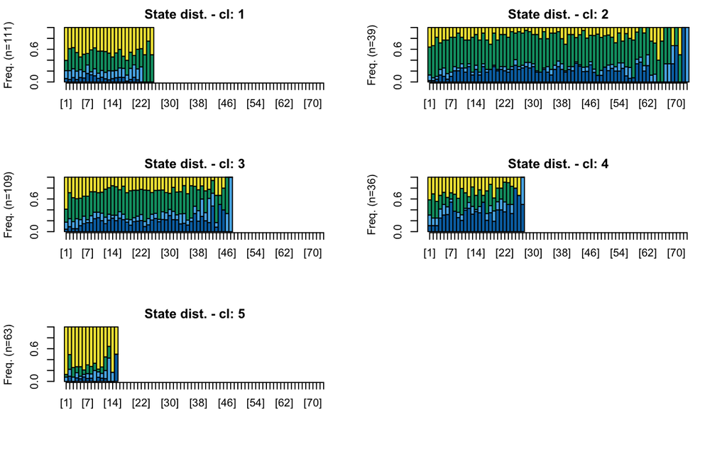

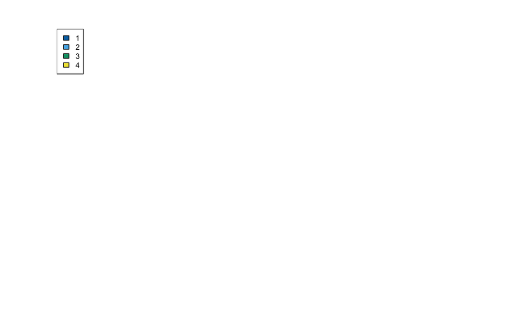

```r
## check the solution with 5 clusters
cl5 <- examine.clusters(cl.mod = seq.ward, n.clust = 5,
                        custom.pallet = cpallet.4st)
```

```
clusters
  1   2   3   4
147  39 109  63
```

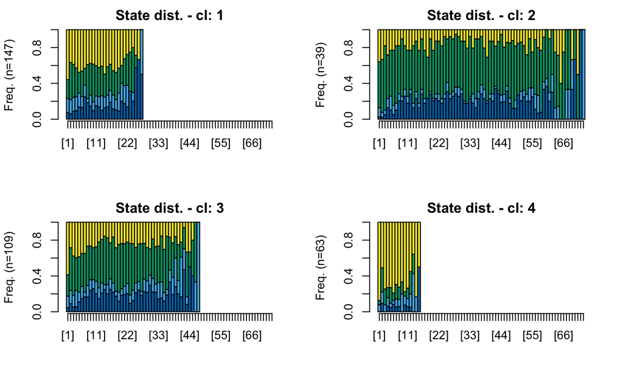

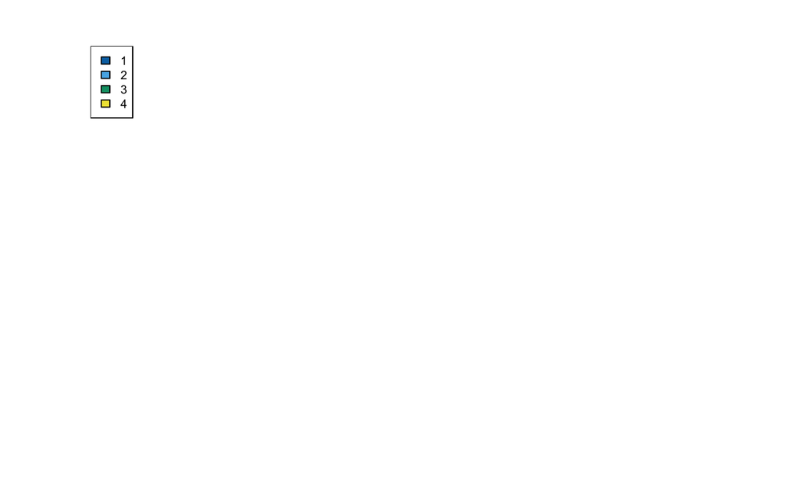

```r
## check the solution with 4 clusters
cl4 <- examine.clusters(cl.mod = seq.ward, n.clust = 4, cpallet.4st)
```

#### Compare the clusters w.r.t. the students’ exam (midterm and final) scores

##### Examine first the 4 clusters model

Compute the summary statistics for the students’ exam scores

```r
cl4.stats <- summary.stats(clusts.w7to12[,c(4,5)], clusts.w7to12$cl4, 4)
kable(x = cl4.stats)
```

| attributes | Median; (Q1, Q3) | Median; (Q1, Q3) | Median; (Q1, Q3) | Median; (Q1, Q3) |
| --- | --- | --- | --- | --- |
| cluster | 1 | 2 | 3 | 4 |
| freq | 147 | 39 | 109 | 63 |
| SC_FE_TOT | 18.67; (14, 27.67) | 28; (18.33, 35.33) | 25.33; (18.5, 31.83) | 15; (10, 21.33) |
| SC_MT_TOT | 14; (12, 17) | 17; (14, 19) | 16; (14, 18) | 12; (9, 16) |

Use statistical test (Kruskal-Wallis) to examine differences across the clusters:

```r
kruskal.test(clusts.w7to12$SC_FE_TOT ~ clusts.w7to12$cl4)
```

```
    Kruskal-Wallis rank sum test

data:  clusts.w7to12$SC_FE_TOT by clusts.w7to12$cl4
Kruskal-Wallis chi-squared = 46.261, df = 3, p-value = 4.99e-10
```

Do pair-wise comparisons using the Mann-Whitney U Test; FDR correction is used to avoid family-wise error:

```r
stud.4cl.df <- clusts.w7to12[,c(1,3:5)]
colnames(stud.4cl.df)[2] <- "class"
kable(pairwise.exam.compare(4, 6, stud.4cl.df, "FE"))
```

|  | c1 | c2 | Z | p | r | significant | alpha |
| --- | --- | --- | --- | --- | --- | --- | --- |
| 5 | 2 | 4 | 5.1922 | 0.000000 | 0.5141 | YES | 0.0083333 |
| 6 | 3 | 4 | 5.4267 | 0.000000 | 0.4138 | YES | 0.0166667 |
| 1 | 1 | 2 | -3.8935 | 0.000074 | 0.2855 | YES | 0.0250000 |
| 2 | 1 | 3 | -3.8605 | 0.000101 | 0.2413 | YES | 0.0333333 |
| 3 | 1 | 4 | 2.8800 | 0.003811 | 0.1987 | YES | 0.0416667 |
| 4 | 2 | 3 | 1.5344 | 0.125556 | 0.1261 | NO | 0.0500000 |

Check the difference based on the midterm score:

```r
kruskal.test(clusts.w7to12$SC_MT_TOT ~ clusts.w7to12$cl4)
```

```
    Kruskal-Wallis rank sum test

data:  clusts.w7to12$SC_MT_TOT by clusts.w7to12$cl4
Kruskal-Wallis chi-squared = 31.056, df = 3, p-value = 8.271e-07
```

Apply Mann-Whitney U Test to do pair-wise comparisons:

```r
kable(pairwise.exam.compare(4, 6, stud.4cl.df, "MT"))
```

|  | c1 | c2 | Z | p | r | significant | alpha |
| --- | --- | --- | --- | --- | --- | --- | --- |
| 6 | 3 | 4 | 4.6014 | 0.000003 | 0.3509 | YES | 0.0083333 |
| 5 | 2 | 4 | 4.0997 | 0.000027 | 0.4059 | YES | 0.0166667 |
| 2 | 1 | 3 | -3.2201 | 0.001219 | 0.2013 | YES | 0.0250000 |
| 1 | 1 | 2 | -3.0767 | 0.001904 | 0.2256 | YES | 0.0333333 |
| 3 | 1 | 4 | 2.3954 | 0.016359 | 0.1653 | YES | 0.0416667 |
| 4 | 2 | 3 | 0.8972 | 0.371727 | 0.0737 | NO | 0.0500000 |

In the case of both midterm and final exams, significant difference w.r.t. the exam scores is present among all pairs of clusters except for the cluster pair 2-3.

##### Now, the same for 5 cluster model

Compute the summary statistics for the students’ exam scores:

```r
cl5.stats <- summary.stats(clusts.w7to12[,c(4,5)], clusts.w7to12$cl5, 5)
kable(x = cl5.stats)
```

| attributes | Median; (Q1, Q3) | Median; (Q1, Q3) | Median; (Q1, Q3) | Median; (Q1, Q3) | Median; (Q1, Q3) |
| --- | --- | --- | --- | --- | --- |
| cluster | 1 | 2 | 3 | 4 | 5 |
| freq | 111 | 39 | 109 | 36 | 63 |
| SC_FE_TOT | 18.67; (14.67, 25.33) | 28; (18.33, 35.33) | 25.33; (18.5, 31.83) | 22.67; (12.5, 32.42) | 15; (10, 21.33) |
| SC_MT_TOT | 14; (11.5, 17) | 17; (14, 19) | 16; (14, 18) | 16; (12.75, 17.25) | 12; (9, 16) |

Examine differences across the clusters:

```r
kruskal.test(clusts.w7to12$SC_FE_TOT ~ clusts.w7to12$cl5)
```

```
    Kruskal-Wallis rank sum test

data:  clusts.w7to12$SC_FE_TOT by clusts.w7to12$cl5
Kruskal-Wallis chi-squared = 48.341, df = 4, p-value = 8.015e-10
```

Pair-wise comparisons using the Mann-Whitney U Test (with FDR correction):

```r
stud.5cl.df <- clusts.w7to12[,c(1,2,4,5)]
colnames(stud.5cl.df)[2] <- "class"
kable(pairwise.exam.compare(5, 10, stud.5cl.df, "FE"))
```

|  | c1 | c2 | Z | p | r | significant | alpha |
| --- | --- | --- | --- | --- | --- | --- | --- |
| 7 | 2 | 5 | 5.1922 | 0.000000 | 0.5141 | YES | 0.005 |
| 9 | 3 | 5 | 5.4267 | 0.000000 | 0.4138 | YES | 0.010 |
| 2 | 1 | 3 | -4.2890 | 0.000015 | 0.2892 | YES | 0.015 |
| 1 | 1 | 2 | -4.1554 | 0.000022 | 0.3393 | YES | 0.020 |
| 4 | 1 | 5 | 2.5651 | 0.010074 | 0.1945 | YES | 0.025 |
| 10 | 4 | 5 | 2.4955 | 0.012152 | 0.2508 | YES | 0.030 |
| 6 | 2 | 4 | 2.0714 | 0.038052 | 0.2392 | NO | 0.035 |
| 5 | 2 | 3 | 1.5344 | 0.125556 | 0.1261 | NO | 0.040 |
| 3 | 1 | 4 | -1.4056 | 0.160828 | 0.1159 | NO | 0.045 |
| 8 | 3 | 4 | 1.0890 | 0.278013 | 0.0904 | NO | 0.050 |

Check the difference based on the midterm score:

```r
kruskal.test(clusts.w7to12$SC_MT_TOT ~ clusts.w7to12$cl5)
```

```
    Kruskal-Wallis rank sum test

data:  clusts.w7to12$SC_MT_TOT by clusts.w7to12$cl5
Kruskal-Wallis chi-squared = 32.366, df = 4, p-value = 1.611e-06
```

Apply Mann-Whitney U Test to do pair-wise comparisons

```r
kable(pairwise.exam.compare(5, 10, stud.5cl.df, "MT"))
```

|  | c1 | c2 | Z | p | r | significant | alpha |
| --- | --- | --- | --- | --- | --- | --- | --- |
| 9 | 3 | 5 | 4.6014 | 0.000003 | 0.3509 | YES | 0.005 |
| 7 | 2 | 5 | 4.0997 | 0.000027 | 0.4059 | YES | 0.010 |
| 2 | 1 | 3 | -3.4609 | 0.000497 | 0.2333 | YES | 0.015 |
| 1 | 1 | 2 | -3.2399 | 0.001054 | 0.2645 | YES | 0.020 |
| 10 | 4 | 5 | 2.3794 | 0.016916 | 0.2391 | YES | 0.025 |
| 4 | 1 | 5 | 2.0021 | 0.045151 | 0.1518 | NO | 0.030 |
| 6 | 2 | 4 | 1.7461 | 0.081252 | 0.2016 | NO | 0.035 |
| 8 | 3 | 4 | 1.1604 | 0.247556 | 0.0964 | NO | 0.040 |
| 3 | 1 | 4 | -1.1521 | 0.250940 | 0.0950 | NO | 0.045 |
| 5 | 2 | 3 | 0.8972 | 0.371727 | 0.0737 | NO | 0.050 |

For midterm, a significant difference is present for 5 out of 10 pairs, whereas for the final exam, a significant difference is detected between 6 out of 10 cluster pairs. Since there is no stat. significant difference between clusters 1 and 4 and these two clusters were merged in one in the 4 cluster solution, it is probably better to *choose the 4 cluster solution* instead of the 5 cluster model.

#### Examine further the clustering models by comparing the clusters based on proportion of the different states (study tactics) in the students’ state sequences

##### The 4 cluster model

Compare state counts in the 4 cluster solution:

```r
cl4.st4.stats <- summary.stats(stud.states.clust[,c(2:6)], stud.states.clust$cl4, 4)
kable(cl4.st4.stats)
```

| attributes | Median; (Q1, Q3) | Median; (Q1, Q3) | Median; (Q1, Q3) | Median; (Q1, Q3) |
| --- | --- | --- | --- | --- |
| cluster | 1 | 2 | 3 | 4 |
| freq | 32 | 113 | 111 | 102 |
| ST1_CNT | 4; (2, 6) | 8; (5, 11) | 2; (1, 4) | 0; (0, 1) |
| ST2_CNT | 1; (0, 3.25) | 3; (1, 6) | 1; (0, 2) | 1; (0, 3) |
| ST3_CNT | 4; (2, 5.25) | 20; (14, 29) | 8; (6.5, 11) | 2; (1, 3) |
| ST4_CNT | 3; (1, 4.25) | 9; (6, 10) | 9; (7, 10) | 8; (6, 10) |
| ST_TOTAL | 13.5; (8.75, 18.5) | 41; (33, 51) | 21; (18, 25) | 12; (10, 16) |

Compare the proportion of states in the 4 clusters solution:

```r
cl4.st4.perc <- summary.stats(stud.states.perc[,c(2:6)], stud.states.perc$cl4, 4)
kable(cl4.st4.perc)
```

| attributes | Median; (Q1, Q3) | Median; (Q1, Q3) | Median; (Q1, Q3) | Median; (Q1, Q3) |
| --- | --- | --- | --- | --- |
| cluster | 1 | 2 | 3 | 4 |
| freq | 147 | 39 | 109 | 63 |
| ST1_PERC | 0.08; (0, 0.21) | 0.2; (0.15, 0.23) | 0.18; (0.09, 0.24) | 0; (0, 0.09) |
| ST2_PERC | 0.1; (0, 0.19) | 0.04; (0.02, 0.09) | 0.09; (0.03, 0.15) | 0.08; (0, 0.17) |
| ST3_PERC | 0.32; (0.2, 0.4) | 0.59; (0.52, 0.62) | 0.44; (0.38, 0.51) | 0.14; (0, 0.19) |
| ST4_PERC | 0.44; (0.33, 0.53) | 0.16; (0.14, 0.2) | 0.28; (0.22, 0.33) | 0.73; (0.62, 0.82) |
| ST_TOTAL | 18; (15, 21) | 55; (50.5, 61) | 32; (28, 37) | 11; (8, 12) |

Use a statitical test to compare the clusters with respect to each of the STx_PERC, x=1:4 variables

```r
for(v in 2:5)
  print(kruskal.test(as.vector(stud.states.perc[,v]) ~ stud.states.perc$cl4))
```

```
    Kruskal-Wallis rank sum test

data:  as.vector(stud.states.perc[, v]) by stud.states.perc$cl4
Kruskal-Wallis chi-squared = 71.819, df = 3, p-value = 1.74e-15


    Kruskal-Wallis rank sum test

data:  as.vector(stud.states.perc[, v]) by stud.states.perc$cl4
Kruskal-Wallis chi-squared = 7.3788, df = 3, p-value = 0.06076


    Kruskal-Wallis rank sum test

data:  as.vector(stud.states.perc[, v]) by stud.states.perc$cl4
Kruskal-Wallis chi-squared = 191.69, df = 3, p-value < 2.2e-16


    Kruskal-Wallis rank sum test

data:  as.vector(stud.states.perc[, v]) by stud.states.perc$cl4
Kruskal-Wallis chi-squared = 210.42, df = 3, p-value < 2.2e-16
```